# Homework number 9: Simulation challenge

**Assignment:** You should analyze one of the student-created datasets described below.

If you are in group `g`, then please analyze dataset `g+1`, wrapping around: so for instance, group 1 analyzes dataset 2; group 4 analyzes dataset 5, and group 7 analyzes dataset 1. (In other words, you analyze dataset `g %% 7 + 1`.)

Your group should produce two things:

- A **presentation**, to be done in class on Thursday, December 3rd. The presentation should be 8 minutes long, and should be done from a single set of slides, but all group members should present some of the slides (contact me if this is a problem). Be sure to cover (a) the motivation and background; (b) some exploratory visualization of the data and any data cleaning if necessary; (c) your model and why you chose it; and (d) conclusions/takeaways.
- A **report** covering your analysis, in the usual style of homework reports for this class. The report may be written and submitted together on Canvas, and should be submitted along with the slides for the presentation.

## Dataset 1: Frogs

A university lab which studies amphibian populations has raised concerns about local northern leopard frog populations. They have found that the ponds seem to contain a low percentage of male frogs. The lab is in turmoil over these results and is desperately trying to understand the underlying cause. You are the Principal Investigator tasked with analyzing the collected data and identifying what is behind this shift. The postdoc in the lab, who leads the research on environmental pollutants, suggests that it is being caused by the local wastewater treatment plant, which discharges treated water carrying hormones and endocrine-disrupting chemicals from things like birth control and pharmaceuticals. He has gone ahead and calculated the distance in kilometers of each pond from the wastewater treatment plant to assist in your analysis. The graduate student in the lab has been analyzing the water samples and has found elevated levels of pollutants from local industrial farming operations, and suggests that these pollutants, including fertilizers and pesticides, could be affecting frog development. The undergrad, who has been assisting with fieldwork and data collection, reports that they have anecdotally noticed fewer male frogs in the fall and spring when it’s cold outside.

The lab collected sampling data from 4 local frog ponds from 2015 to 2024. Researchers made one trip to each pond every spring, summer, and fall (no sampling was done in winter), and each row of the dataset represents one of these trips. During each trip they caught as many frogs as they could in a 6-hour period. Each frog was sexed in the field and released back into the pond, and the total number of frogs caught and the number of females were recorded. Water samples were taken and measured for temperature (°C), pH, and atrazine levels (µg/L), a common herbicide. The four ponds included in the study were:

- Farm Pond: This pond is located on a local farm adjacent to agricultural fields.
- Cedar Marsh: This pond is located in a natural marsh area which is directly adjacent to the local wastewater treatment plant.
- Country Club: This pond is located within the grounds of a local country club, surrounded by managed lawns and one of the largest golf course areas in the region.
- Fern Creek: This pond is located along a small creek in a forested area, relatively isolated from direct human activities.

It is your job as the principal investigator to resolve this conundrum and ease tension in the lab. Using the collected data, determine which of the suspected causes are related to the proportion of female frogs in the ponds, and how strongly.

*Dataset:* frogs.csv

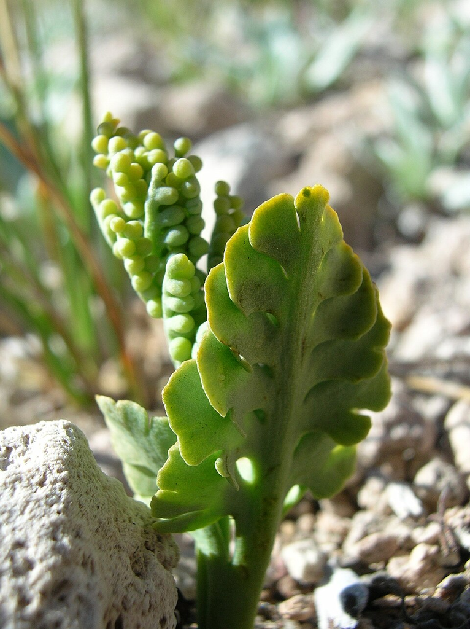

*B. pumicola*, by Gauna via [wikimedia](https://en.wikipedia.org/wiki/File:MDF_Botrychium_pumicola_01.JPG)

## Dataset 2: Moonwort

Our research group has been collecting data on a rare species of moonwort - *Botrychium pumicola*. This species occurs in a narrow range in Eastern Oregon, where it grows at high-elevation locations on pumice gravel. This species is of conservation interest to multiple land management agencies throughout the state. Thus far, our group has surveyed multiple sites across multiple years. In summary, we’ve surveyed multiple plots at a survey location, and recorded for each site how many plots are at that site (`n_plots`), at how many of those plots the moonwort was present (`n_present`), what elevation the site is at (`elevation_m`, in meters), and the average snow fall a survey site received that year (`snow_in`, in inches). We would like to determine if and how the probability of species detection changes based on survey site characteristics.

*Dataset:* moonwort.csv

## Dataset 3: Monarchs

Western monarch butterfly are an iconic species whose overwintering populations have declined an estimate 99% since the 1990s, warranting a review to be listed under the Endangered Species Act. You are a group of researches working in eastern Oregon sagesteppe habitat which is key breeding habitat for this species along its migration. You want to know how monarch larval survival is influenced by specific habitat conditions to support returns to overwintering populations.

To investigate this question, you conducted a field experiment using 100 enclosures per combination of host plant and microclimate (3 host plants x 3 climates x 100 replicates = 900 observations), each containing 10 monarch eggs. You manipulated two habitat factors: host plant (*A. speciosa*, *A. fascicularis*, and *A. cordifolia*) and microclimate (full shade, partial shade, sun). Together these treatments created nine microhabitat (host plant x microclimate) treatments. You monitored survival in each enclosure and recorded the number of individuals that survived to adulthood (`n_surv`) and the number that did not (`n_dead`).

You goal is to determine how hostplant, microclimate, and microhabitat influence western monarch butterfly larval survival.

*Dataset:* monarchs.csv

## Dataset 4: Tootsie pops

At the University of Oregon’s annual Science Saturday open house, 162 volunteers took part in the Great Tootsie Pop Lick Census to settle a decades-old question. Before tasting, each volunteer reported their gender, had the width of their tongue measured with calipers at its widest point, and had their saliva tested with a handheld digital pH meter. To measure licking speed, each volunteer licked a plain warm-up lollipop for 30 seconds while a counter tallied licks. This was then converted to licks per minute. Volunteers then drew a single Tootsie Pop at random from a bag of mixed flavors and were asked to lick it until the chocolate center first became visible. A trained counter recorded the total number of licks with a hand clicker.

The dataset contains for each taster: an ID; their gender (male/female/nonbinary); tongue width in mm; saliva pH; the number of licks per minute on the warm-up lollipop (`licks_per_minute`), flavor of the test tootsie pop (`flavor`), and the number of licks to reach the center on the test tootsie pop (`licks_to_center`).

What determines how many licks it takes to get to the center of a Tootsie Pop? Which characteristics of the taster or lollipop make a difference, and how big is each effect? For example, how many more or fewer licks would you expect from someone whose measurements differ from the typical volunteer? (The world may never know…)

*Dataset:* tootsiepop.csv

## Dataset 5: the Perfectly Peeled Egg

Who hasn’t been there? You boil some eggs, start peeling, and the shell breaks into tiny pieces and takes half of the egg white with it. You try again, slowly and carefully this time… and the next egg looks like it lost a fight. Your hands are wet, there are little shells everywhere, and you are hungry. The internet only makes it worse: one video says brown eggs peel better, another says to use old eggs, someone’s grandmother insists on salt in the water, a blog swears by vinegar, a chef shouts “ICE WATER!” at the camera, and someone in the comments says to just cook them longer. But don’t worry: Emily decided to take matters into her own hands. Over six months, she hard-boiled 500 eggs, one at a time, and wrote down the color of the shell (`shell_color`), how many minutes it cooked after the water started boiling (`cooking_time_minutes`), what she added to the water (`water_trick`: salt, vinegar, or none), how many days the egg had been in her fridge since she bought it (`days_in_fridge`), and whether she put it in ice water right after cooking (`ice_bath`). Then she peeled each egg and wrote down whether it peeled perfectly (`peeled_perfectly`: 1 = the shell came off cleanly and the egg white was not damaged, 0 = it did not).

Your mission: Help Emily separate the facts from the myths. Using her notes, find out which of the things she recorded really change the chance that an egg peels perfectly, and how big each difference is.

*Dataset:* eggs.csv

## Dataset 6: Trout

Oregon Department of Fish and Wildlife (ODFW) has been running a trout monitoring program on tributaries of the Willamette River near Eugene, OR. To survey wild trout populations, they use electroshocking and collect about 95% of the total fish in a 100-meter reach of the stream. After shocking, they identify each trout’s species (Rainbow trout or Cutthroat) and determine whether it is wild or stocked based on an intact adipose fin. Surveys do not count stocked trout. ODFW also records water temperature in Celsius at the time of electroshocking.

Each row in the dataset contains information about a survey: an ID for the particular section of stream (`survey_ID`); whether the reach was stocked with hatchery trout or not (`stocked`); the temperature in Celsius (`water_temp`); a species (cutthroat or rainbow; `species`); and the number of fish of that species seen (`count`).

This past summer was particularly hot, and ODFW started stocking new reaches of some tributaries that spring. ODFW wants you to help them analyze their latest summer survey data to determine whether these changes in environmental conditions (stocking and water temperature) are affecting wild trout populations, and whether one species should be of greatest concern.

*Dataset:* trout.csv

## Dataset 7: Rainfall

This is a data set from a single weather station. This data set contains four variables: Rainfall in units of millimeters per day (mm/day), Cloud fraction as percent of total area covered directly above the station (%), atmospheric pressure in hectopascals (hPa) and downwelling long wave radiation in watts per square meter (W/m2). Each observation is the monthly average of 6 hourly measurements for each month over the past 30 years. Scientists want to understand if these variables climatology (climatology meaning monthly averages over 30 years) are good predictors of rainfall climatology. Based on a theoretical understanding of atmospheric physics, they have hypothesized all of these variables could be good predictors, but need real data to confirm if this is true. To answer this they need you to analyze the data and figure out which variables are important and if any are not important.

Understanding the climate variables that control climatological rainfall will help forecast how regional rainfall might change under future climate change scenarios. This knowledge is important for food and water security, flood and drought preparedness and ecological health.

*Dataset:* rainfall.csv